# DATS6101_Midterm_Proj_q1

Annie Cheng

2024-10-14

```r
library(stringr)
library(tidyverse)
library(dplyr)
library(car)
library(PMCMRplus)
library(here)
# load the cleaned data frame
dataset <- read_csv(here("dataset", "cleaned_FARS.csv"))
```

# 2. Temporal Analysis (Hour, Day of Week)

Research Question: How do **temporal factors** affect fatal motor vehicle accidents?

- SMART question 1: How do **day of week** and **hour of day** affect the occurrence and severity of fatal accidents?
- SMART question 2: Does **day of week** affect the day to day variation on total fatalities per day?

## Data Subsetting and Preparation

Subset for temporal question

```r
# Select columns consists of temporal factors (month, day, day_week, hour) and no of fatalities (fatals)
df_temporal <- dataset %>%
  select("monthname",
         "day",
         "day_weekname",
         "hour",
         "fatals")

# Create a new column to stored the date
df_temporal <- df_temporal %>%
  mutate(
    date = as.Date(paste("2022", monthname, day, sep = "-"), format = "%Y-%b-%d"),
    day_type = ifelse(day_weekname %in% c("Saturday", "Sunday"), "Weekend", "Weekday"),
   fatal_category = ifelse(fatals > 1, "multiple", "one"))

# convert into factor variable and set up level
df_temporal$day_weekname <- factor(df_temporal$day_weekname, levels = c("Sunday","Monday", "Tuesday", "Wednesday", "Thursday", "Friday", "Saturday"))
df_temporal$hour <- factor(df_temporal$hour)
```

Check if every date in 2022 is included in the data frame, all dates in 2022 are included.

Frequency Analysis: Day of Week and Weekday vs Weekend This section calculates the frequency of occurrences for each day of the week and categorizes the results into weekdays and weekends.

**Day of Week Analysis**: Sunday to Friday each has frequency of 52 occurrences, while Saturday has 53. The distribution across the days is balanced.

**Weekday vs Weekend Analysis**: Weekdays have a total of 260 counts, and weekends have 105 counts.

## 2.1 Accident Occurence Analysis

### Summary Statistics

#### Hour of Day

```r
# Filter out unknown hour (hour==99)
df_hour <- df_temporal %>%
  filter(hour != 99) %>%
  mutate(hour = droplevels(hour))

df_hour_accidents <- df_hour %>%
  group_by(hour) %>%
  summarise(total_accidents = n())%>%
  ungroup()
df_hour_accidents
```

```
## # A tibble: 24 × 2
##    hour  total_accidents
##    <fct>           <int>
##  1 0                1702
##  2 1                1516
##  3 2                1596
##  4 3                1093
##  5 4                 989
##  6 5                1284
##  7 6                1472
##  8 7                1262
##  9 8                1096
## 10 9                1126
## # ℹ 14 more rows
```

```r
# Top 5 hours with the highest number of fatal accidents
#head(df_hour_accidents[order(df_hour_accidents$total_accidents, decreasing = TRUE), ], 5)
# Top 5 hours with the lowest number of fatal accidents
#head(df_hour_accidents[order(df_hour_accidents$total_accidents), ], 5)
```

The peak hours for the highest number of accidents occur between 6 PM and 10 PM.

#### Day of Week

```r
df_wday_accidents <- df_temporal %>%
  group_by(day_weekname) %>%
  summarise(total_accidents = n())%>%
  ungroup()
df_wday_accidents
```

```
## # A tibble: 7 × 2
##   day_weekname total_accidents
##   <fct>                  <int>
## 1 Sunday                  6098
## 2 Monday                  5010
## 3 Tuesday                 4914
## 4 Wednesday               5101
## 5 Thursday                5270
## 6 Friday                  6030
## 7 Saturday                7057
```

Saturday and Sunday appear to have higher count of fatal accidents than rest of days of week.

### Data Visualization

#### Hour of Day

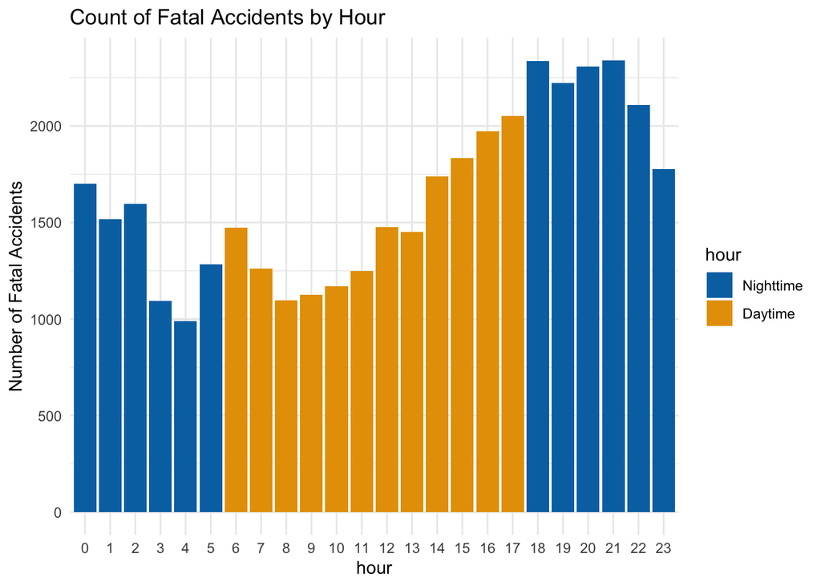

```r
# Count of Fatal Accidents
df_hour %>% ggplot(aes(x= hour, fill = as.numeric(as.character(hour)) >= 6 & as.numeric(as.character(hour)) < 18)) +
  geom_bar()+
  labs(x = "hour", y = "Number of Fatal Accidents",
       title = "Count of Fatal Accidents by Hour",
       fill = "hour")+
  scale_fill_manual(values = c("TRUE" = "#E69F00", "FALSE" = "#0072B2"),
                    labels = c("Nighttime", "Daytime")) +
  theme_minimal()
```

#### Day of Week

[figure not shown]

```r
df_wday_accidents <- df_wday_accidents %>%
  mutate(day_type = ifelse(day_weekname %in% c("Saturday", "Sunday"), "Weekend", "Weekday"))


# Data Visualization on Occurrence of fatal accidents per day of week
df_temporal %>% ggplot(aes(x= day_weekname, fill = day_type)) +
  geom_bar()+
  labs(x = "Day of the Week", y = "Number of Fatal Accidents",
       title = "Frequency of Fatal Accidents by Day of the Week",
       fill = "Day of Week") +
  scale_fill_manual(values = c("#bfbfbf", "#0072B2"),
                    labels = c("weekend", "weekday")) +
  theme_minimal()
```

### Statistical Testing:

We use Chi-squared test to determine whether accidents are uniformly distributed across hours of the day/days of week. #### Hour of Day

```r
# chi-squared test on the occurrence of accident
table(df_hour$hour)
```

```
##
##    0    1    2    3    4    5    6    7    8    9   10   11   12   13   14   15
## 1702 1516 1596 1093  989 1284 1472 1262 1096 1126 1169 1248 1477 1452 1740 1835
##   16   17   18   19   20   21   22   23
## 1974 2052 2335 2223 2309 2340 2110 1777
```

```r
chisq_result <- chisq.test(table(df_hour$hour))
chisq_result
```

```
##
##  Chi-squared test for given probabilities
##
## data:  table(df_hour$hour)
## X-squared = 2675.6, df = 23, p-value < 2.2e-16
```

```r
# Get observed and expected counts
observed <- chisq_result$observed
expected <- chisq_result$expected

# Calculate standardized residuals
standardized_residuals <- (observed - expected) / sqrt(expected)
print(standardized_residuals)
```

```
##
##          0          1          2          3          4          5          6
##   1.723278  -2.880380  -0.900312 -13.349987 -15.924075  -8.622576  -3.969417
##          7          8          9         10         11         12         13
##  -9.167094 -13.275735 -12.533209 -11.468923  -9.513606  -3.845663  -4.464434
##         14         15         16         17         18         19         20
##   2.663810   5.015140   8.455507  10.386073  17.390563  14.618468  16.747041
##         21         22         23
##  17.514317  11.821622   3.579591
```

#### Day of Week

In the dataset, six days have 52 occurrences and one has 53. Even though the days are not perfectly equal but the impact will likely be minimal given the small diffference beteen 52 and 53. For simplicity and common assumption, I will be using equal distribution across all seven days in the test.

```r
# chi-squared test on the occurrence of accident
table(df_temporal$day_weekname)
```

```
##
##    Sunday    Monday   Tuesday Wednesday  Thursday    Friday  Saturday
##      6098      5010      4914      5101      5270      6030      7057
```

```r
chi_sq_test <- chisq.test(table(df_temporal$day_weekname))
print(chi_sq_test)
```

```
##
##  Chi-squared test for given probabilities
##
## data:  table(df_temporal$day_weekname)
## X-squared = 659.78, df = 6, p-value < 2.2e-16
```

```r
# Get observed and expected counts
observed <- chi_sq_test$observed
expected <- chi_sq_test$expected

# Calculate standardized residuals
standardized_residuals <- (observed - expected) / sqrt(expected)
print(standardized_residuals)
```

```
##
##    Sunday    Monday   Tuesday Wednesday  Thursday    Friday  Saturday
##  6.098541 -8.388822 -9.667119 -7.177104 -4.926769  5.193081 18.868192
```

P-value for both test are less than 0.05, indicating that there is a statistically significant deviation from a uniform distribution, suggesting that certain hours and days have higher frequencies of accidents compared to others.

# 3. Severity Analysis

Severity is defined as the number of fatalities per accident. Since the majority of accident has one fatality in an accident and limited occurrence on accidents with fatalities more than four, we will group the number of fatalities into *“one”* and *“multiple”* fatalities.

### Summary Statistics

#### Hour of Day

```r
hr_contingency <- table(df_hour$hour, df_hour$fatal_category)
hr_contingency
```

```
##
##      multiple  one
##   0       131 1571
##   1       128 1388
##   2       130 1466
##   3        92 1001
##   4        72  917
##   5        74 1210
##   6        64 1408
##   7        82 1180
##   8        71 1025
##   9        70 1056
##   10       73 1096
##   11       86 1162
##   12      113 1364
##   13      113 1339
##   14      129 1611
##   15      132 1703
##   16      157 1817
##   17      126 1926
##   18      129 2206
##   19      146 2077
##   20      147 2162
##   21      149 2191
##   22      129 1981
##   23      126 1651
```

#### Day of Week

```r
# Severity: categorize accidents into accident with one fatality and multiple
fatality_counts <- df_temporal %>%
  group_by(day_weekname, fatal_category) %>%
  summarize(count = n())
df_temporal
```

```
## # A tibble: 39,480 × 8
##    monthname   day day_weekname hour  fatals date       day_type fatal_category
##    <chr>     <dbl> <fct>        <fct>  <dbl> <date>     <chr>    <chr>
##  1 January       1 Saturday     12         1 2022-01-01 Weekend  one
##  2 January       1 Saturday     16         2 2022-01-01 Weekend  multiple
##  3 January       1 Saturday     1          1 2022-01-01 Weekend  one
##  4 January       2 Sunday       14         1 2022-01-02 Weekend  one
##  5 January       2 Sunday       18         1 2022-01-02 Weekend  one
##  6 January       2 Sunday       18         1 2022-01-02 Weekend  one
##  7 January       4 Tuesday      9          1 2022-01-04 Weekday  one
##  8 January       4 Tuesday      14         1 2022-01-04 Weekday  one
##  9 January       4 Tuesday      11         1 2022-01-04 Weekday  one
## 10 January       5 Wednesday    0          1 2022-01-05 Weekday  one
## # ℹ 39,470 more rows
```

```r
wday_contingency <- table(df_temporal$day_weekname, df_temporal$fatal_category)
wday_contingency
```

```
##
##             multiple  one
##   Sunday         460 5638
##   Monday         321 4689
##   Tuesday        313 4601
##   Wednesday      330 4771
##   Thursday       339 4931
##   Friday         390 5640
##   Saturday       537 6520
```

### Data Visualization

#### Hour of Day

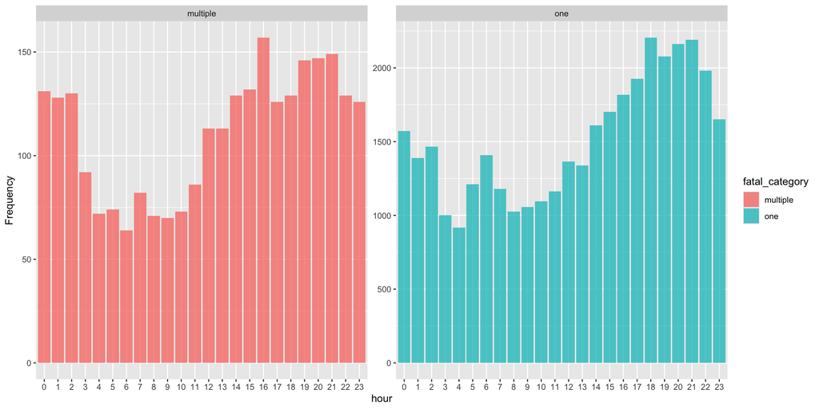

```r
# Convert contingency table into data frame and rename column names
df_hr_contingency <- data.frame(hr_contingency)
colnames(df_hr_contingency)<- c("hour", "fatal_category", "Freq")

#data viz
df_hr_contingency %>%
  ggplot(aes(x= hour, y = Freq, fill = fatal_category))+
  geom_bar(stat="identity", alpha = 0.75) +
  facet_wrap(~ fatal_category, scales = "free_y")+
  labs(y = "Frequency")
```

#### Day of Week

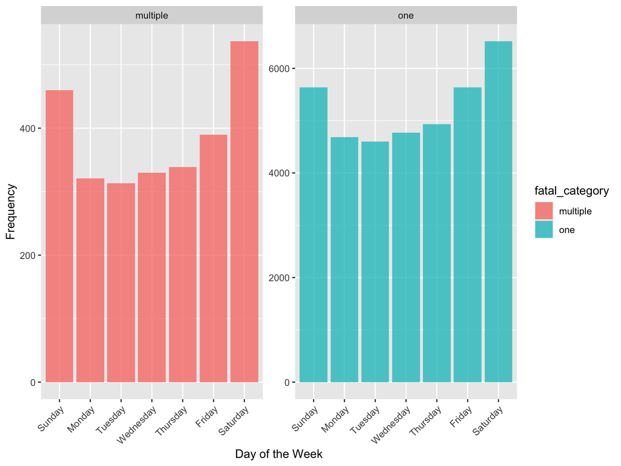

```r
# Convert contingency table into data frame and rename column names
df_wday_contingency <- data.frame(wday_contingency)
colnames(df_wday_contingency)<- c("day_weekname", "fatal_category", "Freq")

# data visualization on Severity by day of week
df_wday_contingency %>% ggplot(aes(x= day_weekname, y = Freq, fill = fatal_category))+
  geom_bar(stat="identity", alpha = 0.75) +
  facet_wrap(~ fatal_category, scales = "free_y")+
  labs(x = "Day of the Week", y = "Frequency") +
  theme(axis.text.x = element_text(angle = 45, hjust = 1))
```

### Statistical Testing

#### Hour of Day

```r
# Chi-squared test: hour of day
chi_sq_result <- chisq.test(hr_contingency)
print(chi_sq_result)
```

```
##
##  Pearson's Chi-squared test
##
## data:  hr_contingency
## X-squared = 55.931, df = 23, p-value = 0.0001447
```

```r
# standardized residuals table
# get the expected and observed values
observed <- chi_sq_result$observed
expected <- chi_sq_result$expected
# calculate the standardized residuals
standardized_residuals <- (observed - expected) / sqrt(expected)
print(standardized_residuals)
```

```
##
##         multiple         one
##   0   1.39749497 -0.37785965
##   1   2.43242033 -0.65768644
##   2   2.03980084 -0.55152859
##   3   2.03235296 -0.54951481
##   4   0.56316755 -0.15227124
##   5  -1.44071351  0.38954523
##   6  -3.62313697  0.97963664
##   7  -0.42879285  0.11593853
##   8  -0.42435726  0.11473922
##   9  -0.76619290  0.20716596
##   10 -0.74406351  0.20118253
##   11  0.10605105 -0.02867446
##   12  1.23384701 -0.33361194
##   13  1.41566765 -0.38277325
##   14  0.96068020 -0.25975212
##   15  0.62494908 -0.16897595
##   16  1.94175859 -0.52501958
##   17 -1.16682546  0.31549041
##   18 -2.38460212  0.64475719
##   19 -0.44250977  0.11964736
##   20 -0.82159741  0.22214642
##   21 -0.82500191  0.22306695
##   22 -1.23002549  0.33257866
##   23  0.44887218 -0.12136765
```

P-value less than 0.05, we can reject the null hypothesis at 5% level of significance. This indicates a significant relationship between the number of fatalities per accident (‘one’ vs. ‘multiple’) and the hour of the day.

#### Day of Week

```r
chi_sq_test<- chisq.test(wday_contingency)
print(chi_sq_test)
```

```
##
##  Pearson's Chi-squared test
##
## data:  wday_contingency
## X-squared = 18.279, df = 6, p-value = 0.005572
```

```r
# Get observed and expected counts
observed <- chi_sq_test$observed
expected <- chi_sq_test$expected

# Calculate standardized residuals
standardized_residuals <- (observed - expected) / sqrt(expected)
print(standardized_residuals)
```

```
##
##               multiple        one
##   Sunday     2.1835233 -0.5904309
##   Monday    -1.1019839  0.2979796
##   Tuesday   -1.1924294  0.3224363
##   Wednesday -0.9419385  0.2547029
##   Thursday  -1.0594320  0.2864734
##   Friday    -1.0290589  0.2782604
##   Saturday   2.5613867 -0.6926062
```

The result reveals a clear pattern in the data, highlighting that weekends are associated with more severe accidents involving multiple fatalities.

## Daily Fatalities

Look further into total fatalities per day to provide a more nuanced undertanding on how does temporal factors affect fatal accidents.

```r
# Data frame for daily fatalities
df_daily <- df_temporal %>%
  group_by(date, day_weekname) %>%
  summarise(
    total_accidents = n(),
    average_fatals = mean(fatals),
    total_fatals = sum(fatals)
  ) %>%
  ungroup()
df_daily <- df_temporal %>%
  group_by(date, day_weekname) %>%
  summarise(
    total_accidents = n(),
    average_fatals = mean(fatals),
    total_fatals = sum(fatals)
  ) %>%
  ungroup()
# convert to the right data type
df_daily$day_weekname <- factor(df_daily$day_weekname, levels =  c("Sunday","Monday", "Tuesday", "Wednesday", "Thursday", "Friday", "Saturday"))
```

### Top 5 Dates with Highest and Lowest Fatalities

```r
# Top 5 Highest Daily Fatalities
head(df_daily[order(df_daily$total_fatals, decreasing = TRUE), ], 5)
```

```
## # A tibble: 5 × 5
##   date       day_weekname total_accidents average_fatals total_fatals
##   <date>     <fct>                  <int>          <dbl>        <dbl>
## 1 2022-09-17 Saturday                 181           1.04          189
## 2 2022-09-24 Saturday                 165           1.13          187
## 3 2022-11-04 Friday                   157           1.17          184
## 4 2022-10-15 Saturday                 163           1.12          183
## 5 2022-05-21 Saturday                 160           1.11          178
```

```r
# Top 5 Lowest Daily Fatalities
tail(df_daily[order(df_daily$total_fatals, decreasing = TRUE), ], 5)
```

```
## # A tibble: 5 × 5
##   date       day_weekname total_accidents average_fatals total_fatals
##   <date>     <fct>                  <int>          <dbl>        <dbl>
## 1 2022-04-05 Tuesday                   72           1.08           78
## 2 2022-01-26 Wednesday                 71           1.08           77
## 3 2022-10-17 Monday                    72           1.07           77
## 4 2022-03-30 Wednesday                 71           1.04           74
## 5 2022-11-16 Wednesday                 69           1.06           73
```

### Data Visualization:Daily fatalities by day of week

```r
# names of days of week
df_daily
```

```
## # A tibble: 365 × 5
##    date       day_weekname total_accidents average_fatals total_fatals
##    <date>     <fct>                  <int>          <dbl>        <dbl>
##  1 2022-01-01 Saturday                 152           1.07          163
##  2 2022-01-02 Sunday                    81           1.11           90
##  3 2022-01-03 Monday                    89           1.16          103
##  4 2022-01-04 Tuesday                   97           1.04          101
##  5 2022-01-05 Wednesday                 91           1.08           98
##  6 2022-01-06 Thursday                  85           1.14           97
##  7 2022-01-07 Friday                   103           1.04          107
##  8 2022-01-08 Saturday                 112           1.12          125
##  9 2022-01-09 Sunday                    86           1.05           90
## 10 2022-01-10 Monday                    89           1.10           98
## # ℹ 355 more rows
```

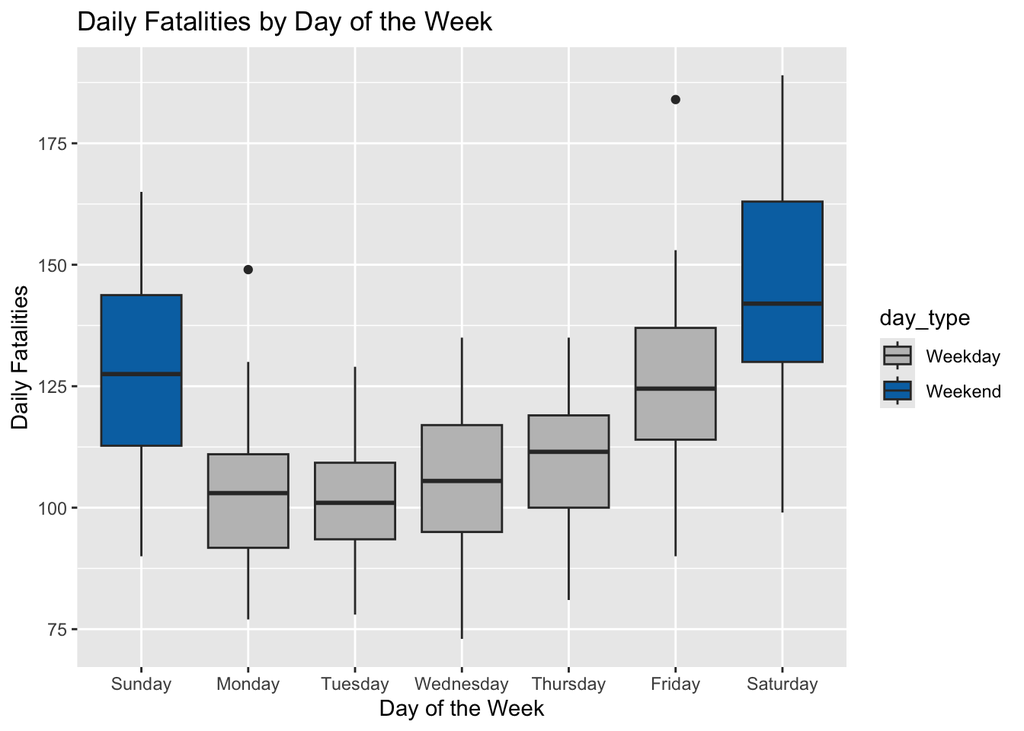

```r
df_daily <- df_daily %>%
  mutate(day_type = ifelse(day_weekname %in% c("Saturday", "Sunday"), "Weekend", "Weekday"))


# Boxplot of daily fatlities by day of week
df_daily %>% ggplot(aes(x = day_weekname, y = total_fatals, fill = day_type))+
  geom_boxplot() +
  labs(x = "Day of the Week",
       y = "Daily Fatalities",
       title = "Daily Fatalities by Day of the Week")+
  scale_fill_manual(values = c("#bfbfbf","#0072B2"))
```

The boxplot shows that daily fatalities are generally higher on weekends. This suggests that weekends tend to have a higher count of fatalities, potentially due to increased travel.

## Summary Statistics of Day of Week

```r
 df_summary_day_week <- df_daily %>%
  group_by(day_weekname) %>%
  summarise(
    sample_size = n(),
    avg_fatalities = mean(total_fatals),
    std_fatalities = sd(total_fatals)) %>%
  ungroup()

df_summary_day_week
```

```
## # A tibble: 7 × 4
##   day_weekname sample_size avg_fatalities std_fatalities
##   <fct>              <int>          <dbl>          <dbl>
## 1 Sunday                52           128.           20.1
## 2 Monday                52           104.           14.8
## 3 Tuesday               52           102.           12.3
## 4 Wednesday             52           106.           15.6
## 5 Thursday              52           109.           13.8
## 6 Friday                52           125.           18.7
## 7 Saturday              53           146.           21.5
```

The average and standard deviation of daily fatalities are notably higher on weekends, indicating both a higher mean and greater variability in fatalities compared to weekdays. The sample size is balanced across groups.

### Check for Normality and Homogeneity of Variance

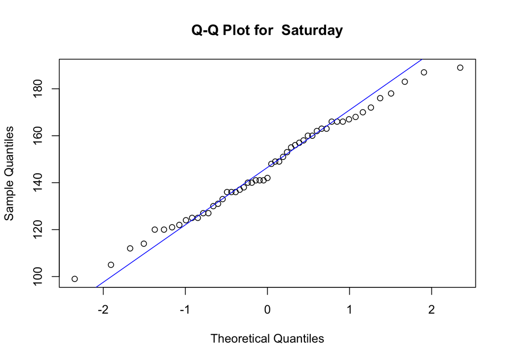

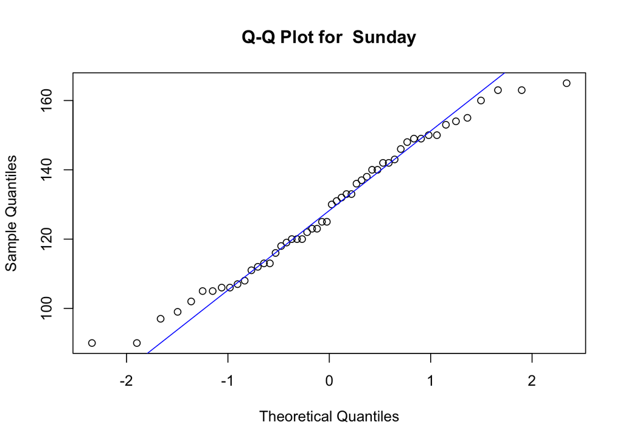

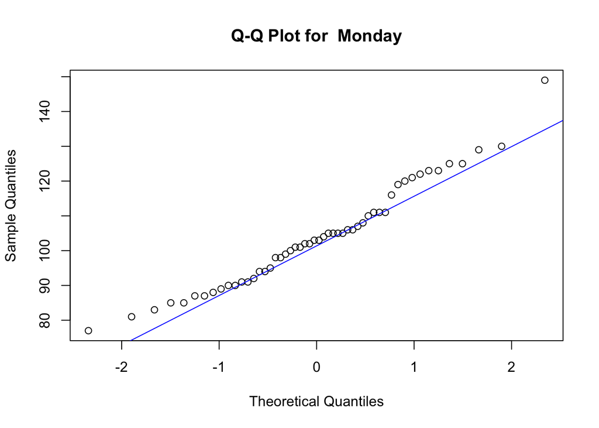

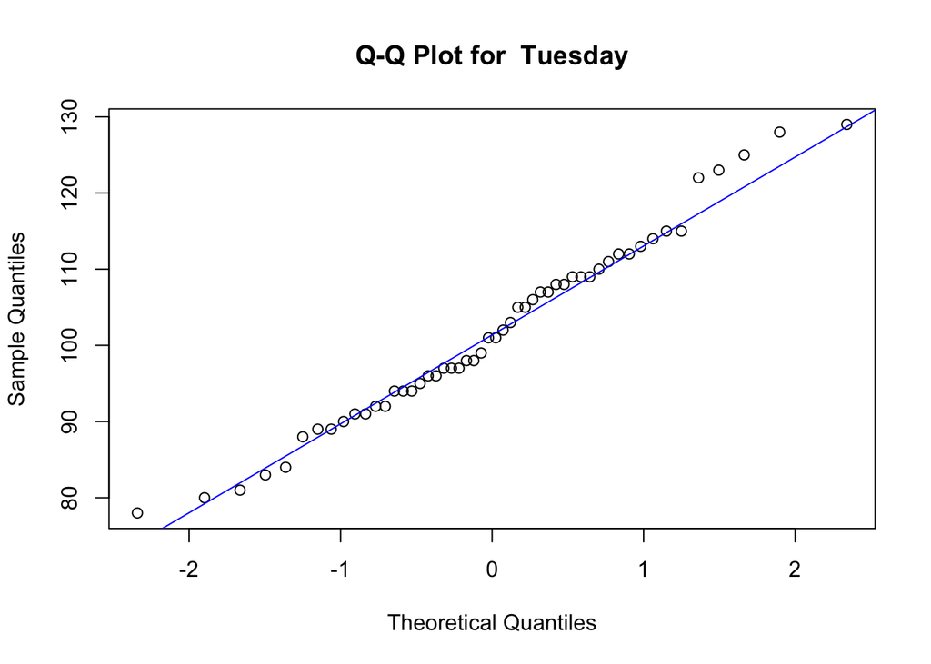

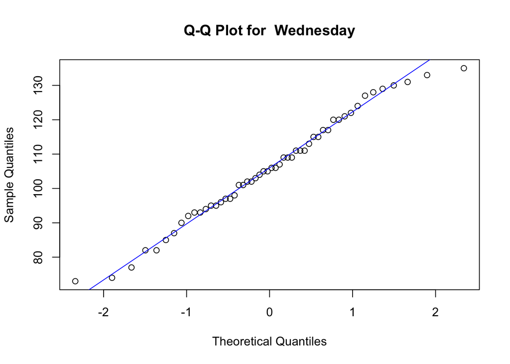

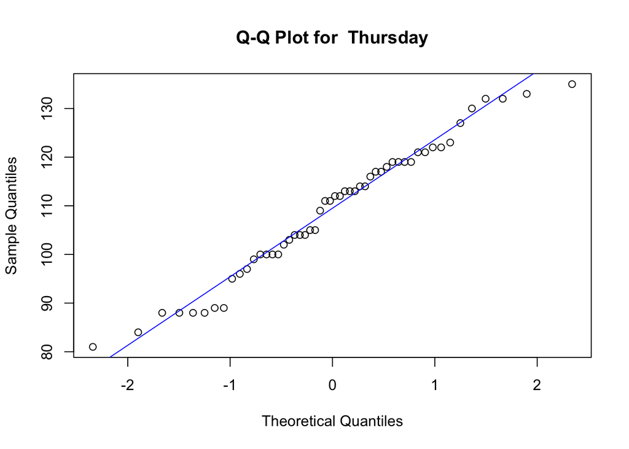

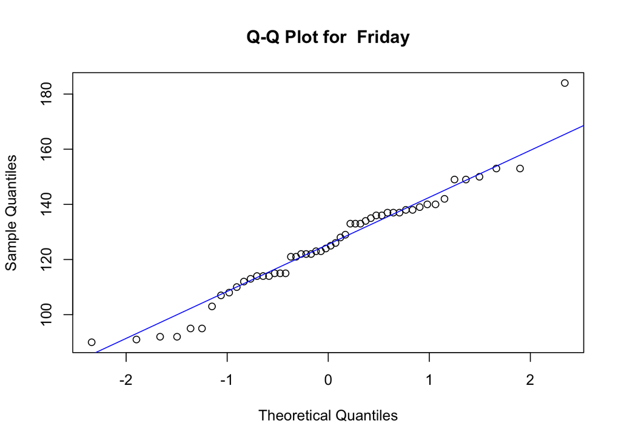

```r
# QQ plot
for(day in unique(df_daily$day_weekname)) {
  qqnorm(df_daily$total_fatals[df_daily$day_weekname == day],
         main = paste("Q-Q Plot for ", day))
  qqline(df_daily$total_fatals[df_daily$day_weekname == day], col = "blue")
}
```

```r
# Shapiro: Normality test
df_daily %>%
  group_by(day_weekname) %>%
  summarise(normality_p_value = shapiro.test(total_fatals)$p.value)
```

```
## # A tibble: 7 × 2
##   day_weekname normality_p_value
##   <fct>                    <dbl>
## 1 Sunday                   0.293
## 2 Monday                   0.174
## 3 Tuesday                  0.582
## 4 Wednesday                0.662
## 5 Thursday                 0.262
## 6 Friday                   0.134
## 7 Saturday                 0.750
```

```r
# Levene test: Homogeneiety of Variance
leveneTest(total_fatals ~ day_weekname, data = df_daily)
```

```
## Levene's Test for Homogeneity of Variance (center = median)
##        Df F value    Pr(>F)
## group   6  4.9755 6.544e-05 ***
##       358
## ---
## Signif. codes:  0 '***' 0.001 '**' 0.01 '*' 0.05 '.' 0.1 ' ' 1
```

Since the number of fatalities per day is relatively large and spans a wide range of values, the daily fatality counts approximate a continuous variable. Combined with sufficiently large sample sizes for each day of the week, the Central Limit Theorem applies, making the sampling distribution of the mean fatalities per day approximately normal. Additionally, normality tests on daily fatalities grouped by day of the week do not reject the assumption of normality. Therefore, we can treat fatalities per day as approximately continuous and appropriately use ANOVA to test for differences across the days of the week

After doing the Leven’s test for homogeneity, we can conclude that the variances across the groups are significantly different at 5% level of significance. This indicates that the homogeneity assumption of ANOVA test is violated. So we will be using Welch’s ANOVA test in the following section

### Statistical Testing

```r
# Welch's ANOVA
Wanova_result <- oneway.test(total_fatals ~ day_weekname, data = df_daily, var.equal = FALSE)
Wanova_result
```

```
##
##  One-way analysis of means (not assuming equal variances)
##
## data:  total_fatals and day_weekname
## F = 41.604, num df = 6.00, denom df = 158.57, p-value < 2.2e-16
```

```r
# post hoc test-Games Howell

posthoc_result <- gamesHowellTest(total_fatals ~ day_weekname, data = df_daily)
print(posthoc_result)
```

```
##
##  Pairwise comparisons using Games-Howell test
```

```
## data: total_fatals by day_weekname
```

```
##           Sunday  Monday  Tuesday Wednesday Thursday Friday
## Monday    5.6e-09 -       -       -         -        -
## Tuesday   2.5e-10 0.98527 -       -         -        -
## Wednesday 1.1e-07 0.99586 0.77825 -         -        -
## Thursday  2.9e-06 0.51490 0.07571 0.90897   -        -
## Friday    0.97767 1.1e-07 1.3e-09 2.3e-06   6.2e-05  -
## Saturday  0.00068 4.9e-10 1.2e-10 4.6e-10   4.0e-10  1.4e-05
```

```
##
## P value adjustment method: none
```

```
## alternative hypothesis: two.sided
```

p-values <0.05, there is a statistically significant difference (p-value < 0.05) in the number of daily fatalities across different days of the week. This indicates that day of week can affect daily fatality counts.